# Computational Modeling Across the Blood-Brain Barrier

#### Members - Alex Luna, Alex Dhupar, Alexis Guth

## Background Information

The goal of this project is to analyze data on existing drugs and their ability to cross the blood-brain barrier (BBB), with the aim of creating a predictive equation and diffusion model that can inform drug design. This model will be based on the chemical and physical properties of drugs known to cross the BBB. By analyzing these descriptors, a mathematical equation will be generated, allowing estimation of LogBB values and visualization of a drug’s ability to cross the BBB.

The package rdkit was used to pull elements of interest out of the molecules provided, based on their SMILES formula, which is a computer-friendly chemical formula for a molecule of interest. The elements of interest that will be analyzed are lipophilicity (MolLogP), molecular weight (MolWt), topological polar surface area (TPSA), formal charge (FC), aromatic rings, and heavy atoms.

These elements were chosen specifically for their impact on the ability of a drug to cross a membrane. Lipophilicity relates to solubility and membrane permeability. Molecular weight and heavy atoms reflect size, which is relevant as larger molecules are unlikely to diffuse across a membrane. TPSA and formal charge capture polarity and ionization, which greatly impact a drug's ability to cross a membrane. An increase in aromatic rings can also impact membrane solubility, as they are generally hydrophobic, making it is easier for drugs to interact with membranes.

These physiochemical elements will be correlated with LogBB, an experimental value included in the dataset that LogBB describes the ratio of drug concentration inside versus outside the BBB, where higher values indicate greater penetration.

The data set used in this Project was sourced from GitHub and contains data from ~7000 drugs with associated BBB permeability data. For this analysis, a subset of ~1000 drugs was selected because it includes experimentally measured LogBB values [1].

As a point of comparison, we reference a publicly available model titled LogBB_Pred that has a similar function of taking a drug and computing its logBB values and reports an $R^2$ of 0.61 [2]. This model will only be used for benchmarking; our work is independent and not based on their methodology.

Topics in this project that connect to BIOL 300/301 coursework include the use of pandas for data handling, opening and manipulating .tsv files, generating ECDFs for data visualization, producing correlation tables to explore relationships between descriptors, exploring different regression models, and including an ODE system.

Finally, we will incorporate a time-based model using Fick’s Law across two compartments (blood and brain). This model applies ordinary differential equations (ODEs) to simulate concentration changes over time, using the following system:

$$ \begin{align} \frac{d C_b}{dt} &= -P_{eff} \cdot (C_b - \frac{C_{br}}{K}) \\ \\ \frac{d C_{br}}{dt} &= P_{eff} \cdot (C_b - \frac{C_{br}}{K} ) \end{align} $$

‌ where $P_{eff}$ is the effective permeability constant, $C_b$ and $C_{br}$ are the blood and brain concentrations, and $K = 10^{\text{LogBB}}$ is the partition ratio predicted by regression.

#### References

[1] F. Meng, Y. Xi, J. Huang, and P. W. Ayers, “A curated diverse molecular database of blood-brain barrier permeability with chemical descriptors,” Scientific Data, vol. 8, no. 1, p. 289, Oct. 2021, doi: https://doi.org/10.1038/s41597-021-01069-5.

[2] B. Shaker et al., “A machine learning-based quantitative model (LogBB_Pred) to predict the blood–brain barrier permeability (logBB value) of drug compounds,” Bioinformatics, vol. 39, no. 10, p. btad577, Oct. 2023, doi: 10.1093/bioinformatics/btad577.

## Data Preparation and Feature Extraction

```python
# if you do not have rdkit installed, run the line of code that contains conda
# this should install rdkit into your current environment

# ! Remove next hashtag at beginning !
# !conda install -c conda-forge rdkit

# alternatively, go to the anaconda website, where rdkit install instructions can be found
# https://anaconda.org/channels/conda-forge/packages/rdkit/overview
```

```python
# import required packages
import numpy as np
import pandas as pd
import seaborn as sns
import matplotlib.pyplot as plt

# Chemical analysis tool
from rdkit import Chem
from rdkit.Chem import Descriptors

# Linear regression
from scipy.stats import linregress
from scipy.integrate import solve_ivp

# machine learning
from sklearn.model_selection import train_test_split
from sklearn.ensemble import GradientBoostingRegressor
from sklearn.metrics import r2_score, mean_absolute_error
from sklearn.linear_model import LinearRegression, LogisticRegression
from sklearn.metrics import accuracy_score

# interactive packages
import holoviews as hv
import panel as pn
```

> This section covers cleaning and preparing the dataset. Compounds missing identifiers (compound name, IUPAC name, or CID) were removed. RDKit was then used to extract the chosen descriptors and add them to the main dataframe.

```python
# data file name for BBB dataset with logBB values
bbb_reg = "../Final Project Comp/B3DB_regression copy.tsv"

# load data
df_regression = pd.read_csv(bbb_reg, sep="\t")
```

```python
df_regression.head()
```

|  | NO. | compound_name | IUPAC_name | SMILES | CID | logBB | Inchi | reference | group | comments |
| --- | --- | --- | --- | --- | --- | --- | --- | --- | --- | --- |
| 0 | 1 | moxalactam | 7-[[2-carboxy-2-(4-hydroxyphenyl)acetyl]amino]... | CN1C(=NN=N1)SCC2=C(N3C(C(C3=O)(NC(=O)C(C4=CC=C... | 3889.0\| | -2.52 | InChI=1S/C20H20N6O9S/c1-25-19(22-23-24-25)36-8... | R25\| | A | NaN |
| 1 | 2 | schembl614298 | (2s,3s,4s,5r)-6-[[(4r,4ar,7s,7ar,12bs)-7-hydro... | CN1CC[C@]23[C@@H]4[C@H]1CC5=C2C(=C(C=C5)OC6[C@... | 18595497.0\| | -2.15 | InChI=1S/C23H27NO9/c1-24-7-6-23-10-3-4-12(25)2... | R25\| | A | NaN |
| 2 | 3 | morphine-6-glucuronide | (2s,3s,4s,5r)-6-[[(4r,4ar,7s,7ar,12bs)-9-hydro... | CN1CC[C@]23[C@@H]4[C@H]1CC5=C2C(=C(C=C5)O)O[C@... | 9847115.0\| | -2.09 | InChI=1S/C23H27NO9/c1-24-7-6-23-10-3-5-13(31-2... | R25\| | A | NaN |
| 3 | 4 | 2-[4-(5-bromo-3-methylpyridin-2-yl)butylamino]... | 2-[4-(5-bromo-3-methylpyridin-2-yl)butylamino]... | CC1=NC=C(C=C1)CC2CNC(NC2=O)NCCCCC3=NC=C(C=C3C)Br | 74041479.0\| | -1.88 | InChI=1S/C21H28BrN5O/c1-14-9-18(22)13-25-19(14... | R35\| | A | NaN |
| 4 | 5 | NaN | NaN | c1(c2c3n(c4c(C(N(C)C3)=O)c(Cl)ccc4)cn2)noc(C(O... | nan\| | -1.82 | InChI=1S/C16H14ClN5O4/c1-16(24,25)15-19-13(20-... | R35\| | A | NaN |

```python
# remove any variables that do not have a compound name
df_main = df_regression[(df_regression['compound_name'].notna())].copy()

# parse through molecular structures and prepare for structure analysis
df_main['Mol'] = df_main['SMILES'].apply(Chem.MolFromSmiles)

# based on molecular structures, add new columns containing elements of interest
df_main['MolLogP'] = df_main['Mol'].apply(Descriptors.MolLogP)
df_main['MolWt'] = df_main['Mol'].apply(Descriptors.MolWt)
df_main['TPSA'] = df_main['Mol'].apply(Descriptors.TPSA)
df_main['FC']    = df_main['Mol'].apply(lambda m: Chem.GetFormalCharge(m))
df_main['Aromatic Rings'] = df_main['Mol'].apply(Descriptors.NumAromaticRings)
df_main['Heavy Atoms'] = df_main['Mol'].apply(Descriptors.HeavyAtomCount)
```

```python
# ensure data frame only consists of elements of interest
df_main = df_main[['NO.', 'compound_name', 'logBB', 'MolLogP', 'MolWt',
                   'TPSA', 'FC', 'Aromatic Rings', 'Heavy Atoms']]
df_main.head()
```

|  | NO. | compound_name | logBB | MolLogP | MolWt | TPSA | FC | Aromatic Rings | Heavy Atoms |
| --- | --- | --- | --- | --- | --- | --- | --- | --- | --- |
| 0 | 1 | moxalactam | -2.52 | -1.12770 | 520.480 | 206.30 | 0 | 2 | 36 |
| 1 | 2 | schembl614298 | -2.15 | -1.23650 | 461.467 | 149.15 | 0 | 1 | 33 |
| 2 | 3 | morphine-6-glucuronide | -2.09 | -0.88540 | 461.467 | 149.15 | 0 | 1 | 33 |
| 3 | 4 | 2-[4-(5-bromo-3-methylpyridin-2-yl)butylamino]... | -1.88 | 2.63014 | 446.393 | 78.94 | 0 | 2 | 28 |
| 6 | 7 | sucrose | -1.70 | -5.39560 | 342.297 | 189.53 | 0 | 0 | 23 |

## Exploratory Data Analysis

### Initial Data Visualization and correlation

> ECDFs and bar charts are used to quickly visualize the raw data and distribution of descriptors and LogBB values. Two methods are provided for reader preference.

```python
def ecdf(data):
    """Generate x and y values for plotting an ECDF."""
    x_vals = np.sort(data)
    y_vals = np.arange(1, len(data)+1) / len(data)

    return x_vals, y_vals
```

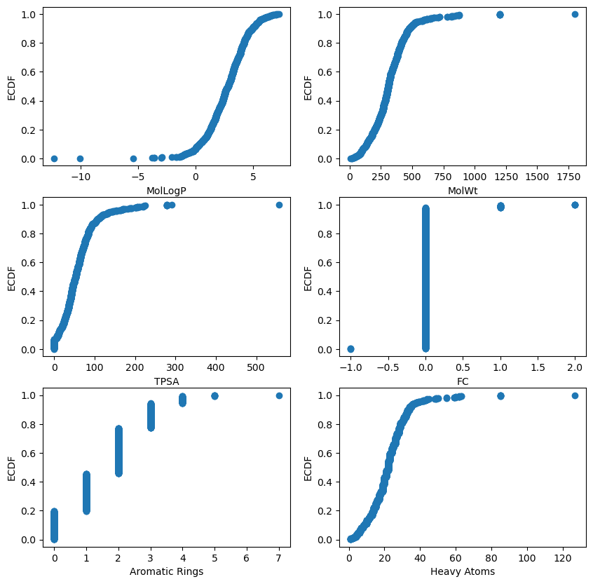

```python
# initialize list of elements and plotting setup
elements = ['MolLogP', 'MolWt', 'TPSA', 'FC', 'Aromatic Rings', 'Heavy Atoms']
fig, axes = plt.subplots(3,2, figsize = (10,10))
axes = axes.flatten()

# loop through elements
for i,elm in enumerate(elements):

    # plotting our data
    x_data, y_data = ecdf(df_main[elm])
    axes[i].scatter(x_data, y_data)
    axes[i].set_xlabel(elm)
    axes[i].set_ylabel('ECDF');
```

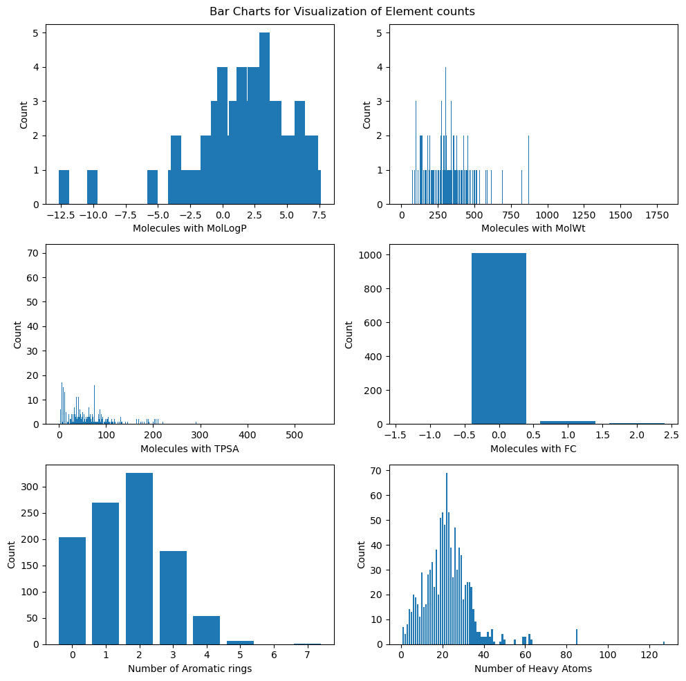

```python
# initialize list of elements and plotting setup
elements = ['MolLogP', 'MolWt', 'TPSA', 'FC', 'Aromatic Rings', 'Heavy Atoms']
fig, axes = plt.subplots(3,2, figsize = (10,10))
axes = axes.flatten()

# loop through elements
for i, elm in enumerate(elements):

    # separate data of element into bins
    bins = df_main[elm].unique().tolist()
    bins.sort()

    # develop count for each bin
    count = []
    for b in bins:
        count.append((df_main[elm] == b).sum())

    # plot data
    axes[i].bar(bins, count)
    axes[i].set_xlabel(f'Molecules with {elm}')
    axes[i].set_ylabel('Count')

# title graph and ensure proper spacing
axes[4].set_xlabel('Number of Aromatic rings')
axes[5].set_xlabel('Number of Heavy Atoms')


fig.suptitle('Bar Charts for Visualization of Element counts')
plt.tight_layout();
```

> In order to visualize any immediate correlation between the LogBB and our chosen Descriptors, correlation graphs are generated in the following section.

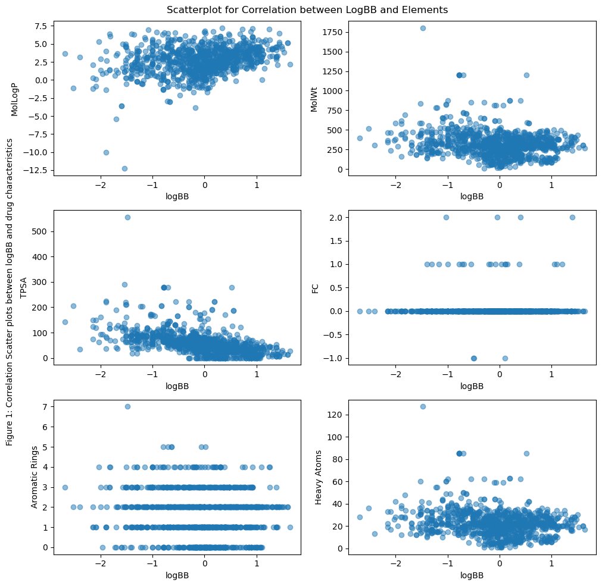

```python
# initialize list of elements and plotting setup
elements = ['MolLogP', 'MolWt', 'TPSA', 'FC', 'Aromatic Rings', 'Heavy Atoms']
fig, axes = plt.subplots(3,2, figsize = (10,10))
axes = axes.flatten()

# loop through elements
for i,elm in enumerate(elements):

    # plot data
    axes[i].scatter(df_main['logBB'], df_main[elm], alpha = 0.5)
    axes[i].set_xlabel('logBB')
    axes[i].set_ylabel(elm)


# title graph and ensure proper spacing
fig.suptitle('Scatterplot for Correlation between LogBB and Elements')
plt.tight_layout()
fig.text(0.001, 0.5, "Figure 1: Correlation Scatter plots between logBB and drug characteristics",
         ha="center", va = 'center', rotation = 90)
fig.savefig('Fig 1 Corr_scatterplot.png', bbox_inches='tight');
```

> While these correlation graphs are somewhat helpful in depicting correlation, the interpretability is somewhat poor, and the data appears very noisy. Thus, a correlation table will be generated to better visualize any correlation.

```python
# make a list of elements
elements = ['logBB', 'MolLogP', 'MolWt', 'TPSA', 'FC', 'Aromatic Rings', 'Heavy Atoms']

# make a correlation table between all chosen elements
corr_table = df_main[elements].corr()

# format table to include a gradient
corr_table.style.background_gradient(cmap='coolwarm') \
                 .format("{:.2f}")
```

|  | logBB | MolLogP | MolWt | TPSA | FC | Aromatic Rings | Heavy Atoms |
| --- | --- | --- | --- | --- | --- | --- | --- |
| logBB | 1.00 | 0.28 | -0.21 | -0.53 | 0.00 | -0.10 | -0.21 |
| MolLogP | 0.28 | 1.00 | 0.41 | -0.24 | -0.11 | 0.53 | 0.41 |
| MolWt | -0.21 | 0.41 | 1.00 | 0.69 | 0.02 | 0.51 | 0.99 |
| TPSA | -0.53 | -0.24 | 0.69 | 1.00 | 0.02 | 0.19 | 0.70 |
| FC | 0.00 | -0.11 | 0.02 | 0.02 | 1.00 | 0.03 | 0.02 |
| Aromatic Rings | -0.10 | 0.53 | 0.51 | 0.19 | 0.03 | 1.00 | 0.54 |
| Heavy Atoms | -0.21 | 0.41 | 0.99 | 0.70 | 0.02 | 0.54 | 1.00 |

### Regression Modelling

> Based on the previous graphs and table, it is clear LogBB is dependent on multiple relations between descriptors. This section uses regression modeling to explore these complex interactions.

#### Simple Linear Regression

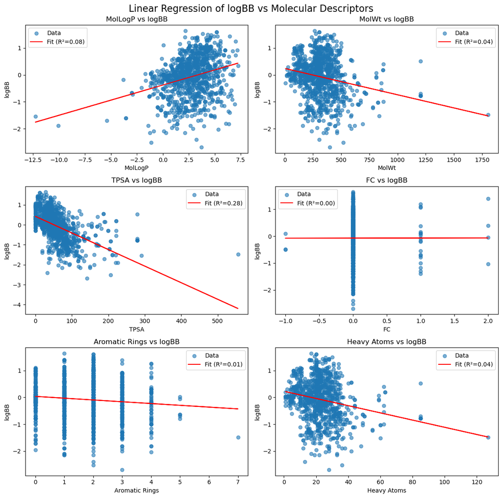

```python
# make a list of elements
elements = ['MolLogP', 'MolWt', 'TPSA', 'FC', 'Aromatic Rings', 'Heavy Atoms']

# set up subplot grid
fig, axes = plt.subplots(3, 2, figsize=(12, 12))
axes = axes.flatten()

# loop through descriptors
for i, elm in enumerate(elements):
    x = df_main[elm]
    y = df_main['logBB']

    # perform linear regression
    slope, intercept, r_value, p_value, std_err = linregress(x, y)

    # scatter plot
    axes[i].scatter(x, y, alpha=0.6, label='Data')

    # regression line
    axes[i].plot(x, intercept + slope*x, color='red', label=f'Fit (R²={r_value**2:.2f})')

    # labels and title
    axes[i].set_xlabel(elm)
    axes[i].set_ylabel('logBB')
    axes[i].set_title(f'{elm} vs logBB')
    axes[i].legend()

# overall title and layout
fig.suptitle('Linear Regression of logBB vs Molecular Descriptors', fontsize=16)
plt.tight_layout()
plt.show()
```

> Simple linear regression was performed for each descriptor against the logBB values using the scipy package. As the above graphs show, this resulted in weak fits, suggesting that multiple linear regression might better capture the complexity.

#### Multiple Linear Regression

```python
# select features and target
X = df_main[['MolLogP', 'MolWt', 'TPSA', 'FC', 'Aromatic Rings', 'Heavy Atoms']].values
y = df_main['logBB'].values

# add intercept column
X_aug = np.column_stack((np.ones(X.shape[0]), X))

# solve using least squares
coeffs, residuals, rank, s = np.linalg.lstsq(X_aug, y, rcond=None)

# print coefficients
print("Intercept:", coeffs[0])
for i, name in enumerate(['MolLogP', 'MolWt', 'TPSA', 'FC', 'Aromatic Rings', 'Heavy Atoms']):
    print(f"{name}: {coeffs[i+1]:.4f}")
```

```
Intercept: 0.24220011257920013
MolLogP: 0.0052
MolWt: -0.0012
TPSA: -0.0127
FC: 0.0553
Aromatic Rings: -0.1340
Heavy Atoms: 0.0464
```

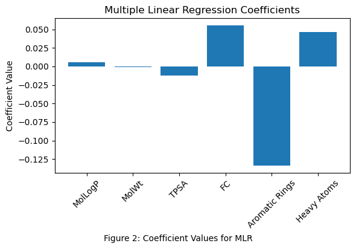

```python
feature_names = ['MolLogP', 'MolWt', 'TPSA', 'FC', 'Aromatic Rings', 'Heavy Atoms']
coef_values = coeffs[1:]  # skip intercept

# plot regression coefficients to show which descriptors matter most
plt.figure(figsize=(6,4))
plt.bar(feature_names, coef_values)
plt.xticks(rotation=45)
plt.ylabel('Coefficient Value')
plt.title('Multiple Linear Regression Coefficients')
plt.tight_layout()
plt.figtext(0.5, -0.01, "Figure 2: Coefficient Values for MLR", ha="center")
plt.savefig('Fig 2 MLR_Coeffs.png', bbox_inches='tight')
plt.show()
```

> Using Least Squares, the weights of our descriptors to use in a multiple linear regression model are calculated, which can be seen in the coefficient plot above.

```
R-squared: 0.3521
```

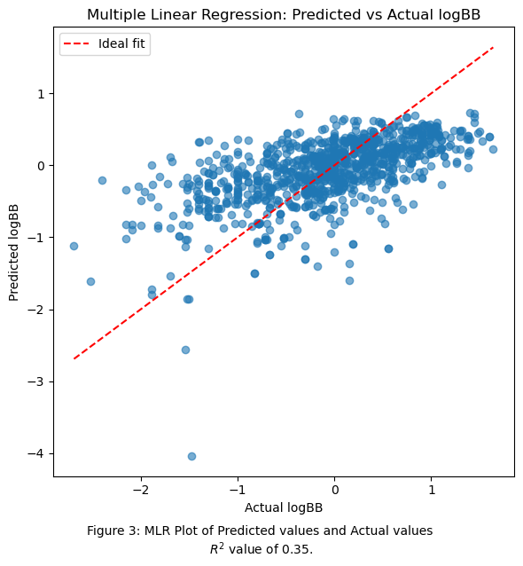

```python
# predicted values
y_pred = X_aug @ coeffs

#calculate correlation coefficient
r = np.corrcoef(y, y_pred)[0, 1]

# Square the value to get R-squared (R2)
r_squared = r**2

# print r-squared value
print(f"R-squared: {r_squared:.4f}")

# plot predicted vs actual
plt.figure(figsize=(6,6))
plt.scatter(y, y_pred, alpha=0.6)
plt.plot([y.min(), y.max()], [y.min(), y.max()], 'r--', label='Ideal fit')
plt.xlabel('Actual logBB')
plt.ylabel('Predicted logBB')
plt.title('Multiple Linear Regression: Predicted vs Actual logBB')
plt.legend()
plt.tight_layout()
plt.figtext(0.5, -0.05, """Figure 3: MLR Plot of Predicted values and Actual values
$R^2$ value of 0.35.""", ha="center")
plt.savefig('Fig 3 MLR_plot.png', bbox_inches='tight')
plt.show()
```

> Using the weights and by calculating the intercept, we were able to plot our predicted LogBB values against actual logBB values with a fit to display the level of accuracy for the multiple linear regression model.

#### Logistic Regression and Classification

> This section focuses on manual logistic regression and the construction of a confusion matrix. The same descriptors (MolLogP, MolWt, TPSA, FC, Aromatic Rings, Heavy Atoms) are used to fit a classifier that predicts BBB permeability as a binary outcome (permeable vs. not permeable). While a confusion matrix table cannot produce a predicted LogBB value, it may offer some insight into the descriptors, as this logistic regression is based on our linear regression data.

```
Confusion Matrix:
 [[532  12]
 [372 120]]
```

[figure not shown]

```python
# prepare features and binary target
X = df_main[['MolLogP', 'MolWt', 'TPSA', 'FC', 'Aromatic Rings', 'Heavy Atoms']].values
y = (df_main['logBB'] > 0).astype(int).values   # 1 if penetrates BBB, else 0

# add intercept column
X_aug = np.column_stack((np.ones(X.shape[0]), X))

# define sigmoid function
def sigmoid(z):
    '''
    Allows for the interpretability of a real number as a probability. Necessary for Linear regression.
    '''
    return 1 / (1 + np.exp(-z))

# gradient descent for logistic regression
def logistic_regression(X, y, lr=0.001, epochs=10000):
    '''
    Run logistic regression based on weights of Feature values, a set learning rate of 0.001, and a 10000 interations.
    '''

    # initiate values and weights
    n_samples, n_features = X.shape
    weights = np.zeros(n_features)

    # adjust weight values base on linear model.
    for _ in range(epochs):

        # calculate dot product between Feature values and weights.
        linear_model = np.dot(X, weights)

        # generate probability
        y_pred = sigmoid(linear_model)

        # gradient
        gradient = np.dot(X.T, (y_pred - y)) / n_samples
        weights -= lr * gradient

    return weights

# train model using adjusted weights
weights = logistic_regression(X_aug, y, lr=0.001, epochs=5000)

# predictions
y_pred_prob = sigmoid(np.dot(X_aug, weights))
y_pred_class = (y_pred_prob >= 0.5).astype(int)


# create confusion matrix, which breaks down correct vs. incorrect predictions
def confusion_matrix(y_true, y_pred):
    '''
    Create a confusion matrix based on true values and predicted values.
    '''

    tp = np.sum((y_true == 1) & (y_pred == 1))
    tn = np.sum((y_true == 0) & (y_pred == 0))
    fp = np.sum((y_true == 0) & (y_pred == 1))
    fn = np.sum((y_true == 1) & (y_pred == 0))
    return np.array([[tn, fp],[fn, tp]])

cm = confusion_matrix(y, y_pred_class)
print("Confusion Matrix:\n", cm)

# visualize confusion matrix
fig, ax = plt.subplots(figsize=(4,4))
im = ax.imshow(cm, cmap='Blues')

ax.set_xticks([0,1])
ax.set_yticks([0,1])
ax.set_xticklabels(['No BBB', 'Yes BBB'])
ax.set_yticklabels(['No BBB', 'Yes BBB'])
plt.xlabel('Predicted')
plt.ylabel('Actual')
plt.title('Confusion Matrix (Manual Logistic Regression)')

# annotate counts
for i in range(cm.shape[0]):
    for j in range(cm.shape[1]):
        ax.text(j, i, cm[i, j], ha='center', va='center', color='black')

plt.tight_layout()
plt.figtext(0.6, -.05, """Figure 4: A confusion matrix base on Logistic Regression
Accuracy of 70.2% as seen in 'Model Comparison and Interpretation' section. """, ha="center")
plt.savefig('Fig 4 LR_CM.png', bbox_inches='tight')
plt.show();
```

> The confusion matrix uses this logic to place the actual logBB value of a compound into 'yes or no' categories, as well as the predicted logBB value, comparing these two classifications against each other.

### Predictive Machine Learning (ML) Model

#### Gradient Boosting

> This section involves a machine learning model, gradient boosting, which works by building an ensemble of decision trees. Each tree corrects the errors of the previous one, allowing the model to capture non‑linear relationships between descriptors and LogBB. Unlike linear regression, descriptors are not used as direct weights but instead contribute to reducing prediction error across the ensemble.

```python
# features and target
X = df_main[['MolLogP','MolWt','TPSA','FC','Aromatic Rings','Heavy Atoms']]
y = df_main['logBB']

# train/test split
X_train, X_test, y_train, y_test = train_test_split(X, y, test_size=0.2, random_state=42)

# train model
gbr = GradientBoostingRegressor(n_estimators=300, learning_rate=0.05, max_depth=3, random_state=42)
gbr.fit(X_train, y_train)

# evaluate
y_pred = gbr.predict(X_test)
print("R²:", r2_score(y_test, y_pred))
print("MAE:", mean_absolute_error(y_test, y_pred))
```

```
R²: 0.35664600043485484
MAE: 0.4368253923664876
```

> Our model, titled 'gbr', was trained on the dataset using the chosen descriptors. As this model has the highest $R^2$ value, we incorporate it into an interactive graph.

#### Interactive Version

```python
# open interactive package
hv.extension('bokeh')

# sliders
MolLogP = pn.widgets.FloatSlider(name="MolLogP", start=-2, end=7, step=0.1, value=2.0)
MolWt   = pn.widgets.IntSlider(name="MolWt", start=50, end=900, step=5, value=350)
TPSA    = pn.widgets.IntSlider(name="TPSA", start=0, end=220, step=1, value=70)
FC      = pn.widgets.IntSlider(name="Formal Charge", start=-3, end=3, step=1, value=0)
Arom    = pn.widgets.IntSlider(name="Aromatic Rings", start=0, end=10, step=1, value=1)
Heavy   = pn.widgets.IntSlider(name="Heavy Atoms", start=5, end=100, step=1, value=30)

# prediction function
def predict_plot(MolLogP, MolWt, TPSA, FC, Arom, Heavy):
    '''
    Uses the values from the sliders to genereate a predictive plot.
    '''

    # initiate slider values and run Gradient boosting regression
    X = np.array([[MolLogP, MolWt, TPSA, FC, Arom, Heavy]])
    pred = gbr.predict(X)[0]

    # use regression data to calculate a K values
    K = 10**pred

    # use K value to help set axes and return plot data
    data = pd.DataFrame({"Compartment":["Blood","Brain"], "Concentration":[1.0, K]})
    return hv.Bars(data, kdims="Compartment", vdims="Concentration").opts(
        title=f"Predicted LogBB={pred:.3f}", width=400, height=300)

# format plot
interactive = pn.bind(predict_plot, MolLogP, MolWt, TPSA, FC, Arom, Heavy)
gbr_plot = pn.Column(MolLogP, MolWt, TPSA, FC, Arom, Heavy, interactive)

gbr_plot
```

> This model utilizes sliders to link numerical values to our chosen physiochemical factors, which are then run through our 'gbr' model, producing a logBB value. This is then broken down into the concentrations by compartment.

### Model Comparison and Interpretation

> This section compares the performance of the different models (multiple linear regression, logistic regression, and gradient boosting). The goal is to evaluate trade‑offs between interpretability and predictive accuracy. As we trained our linear regression model, we achieved a slightly lower $R^2$ value compared to the untrained model.

```
Linear Regression R²: 0.33322533625621964
Logistic Regression Accuracy: 0.7019230769230769
Gradient Boosting R²: 0.35664600043485484
```

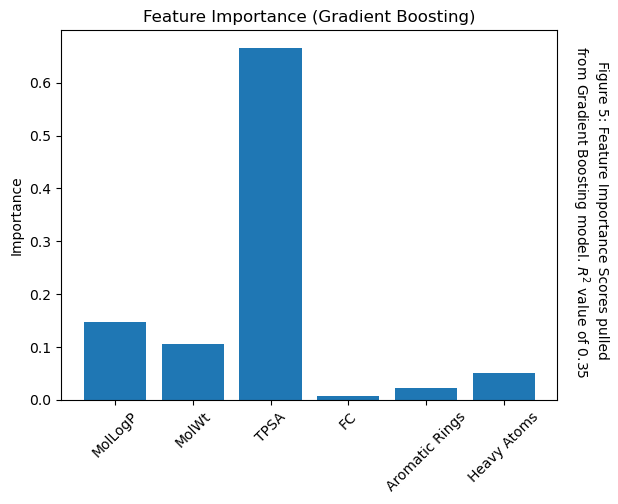

```python
# linear regression (continuous logBB prediction)
linreg = LinearRegression().fit(X_train, y_train)
print("Linear Regression R²:", r2_score(y_test, linreg.predict(X_test)))

# logistic regression (binary classification: logBB > 0)
y_class = (y > 0).astype(int)
X_train_c, X_test_c, y_train_c, y_test_c = train_test_split(X, y_class, test_size=0.2, random_state=42)
logreg = LogisticRegression(max_iter=500).fit(X_train_c, y_train_c)
print("Logistic Regression Accuracy:", accuracy_score(y_test_c, logreg.predict(X_test_c)))

# predictive model (non-linear)
y_pred_gbr = gbr.predict(X_test)
print("Gradient Boosting R²:", r2_score(y_test, y_pred_gbr))

# feature importance from gradient boosting
plt.bar(X.columns, gbr.feature_importances_)
plt.xticks(rotation=45)
plt.ylabel("Importance")
plt.title("Feature Importance (Gradient Boosting)")
plt.figtext(0.95, 0.5, """Figure 5: Feature Importance Scores pulled
from Gradient Boosting model. $R^2$ value of 0.35""", ha='center', va='center',  rotation=270 )
plt.savefig('Fig 5 GB_Feature_imp.png', bbox_inches='tight')
plt.show()
```

> As gradient boosting is a non‑linear model, descriptors do not act as direct weights but instead reduce error iteratively across the predictions.

### Fick's Law-Style Simulation

> Multiple linear regression was chosen for integration into the Fick’s law simulation because it was interpretable and comparable in accuracy to gradient boosting. Fick’s law models diffusion across membranes and can simulate concentration changes over time.

> We used coefficients from the multiple linear regression model as inputs to the Fick’s law equations, linking predicted LogBB values to the partition ratio $K = 10^{\text{LogBB}}$.

```python
# train linear coefficients
linreg = LinearRegression().fit(X_train, y_train)

# coefficients and intercept
coeffs = dict(zip(X.columns, linreg.coef_))
intercept = linreg.intercept_

print("Intercept:", intercept)
print("Coefficients:", coeffs)
```

```
Intercept: 0.24065299382871974
Coefficients: {'MolLogP': -0.01154453610206007, 'MolWt': -0.0013103088337165416, 'TPSA': -0.01325123233416942, 'FC': 0.017173401646982254, 'Aromatic Rings': -0.13227553343071805, 'Heavy Atoms': 0.05121221259911662}
```

```python
# open interactive package
hv.extension('bokeh')

# sliders defined as variables so they can be updated
MolLogP_slider = pn.widgets.FloatSlider(name="MolLogP", start=-2, end=7, step=0.1, value=2.0)
MolWt_slider   = pn.widgets.IntSlider(name="MolWt", start=50, end=900, step=5, value=350)
TPSA_slider    = pn.widgets.IntSlider(name="TPSA", start=0, end=220, step=1, value=70)
FC_slider      = pn.widgets.IntSlider(name="Formal Charge", start=-3, end=3, step=1, value=0)
Arom_slider    = pn.widgets.IntSlider(name="Aromatic Rings", start=0, end=10, step=1, value=1)
Heavy_slider   = pn.widgets.IntSlider(name="Heavy Atoms", start=5, end=100, step=1, value=30)

# dropdown with compound names
drug_select = pn.widgets.Select(name="Choose Drug", options=list(df_main["compound_name"]))


def update_sliders(event):
    '''
    This function updates the sliders with the values of the selected drug.
    '''
    # if a drug is chosen from dropdown, create an event to update slider values.
    drug = event.new
    if drug in df_main["compound_name"].values:
        row = df_main.loc[df_main["compound_name"] == drug].iloc[0]

        MolLogP_slider.value = float(row["MolLogP"])
        MolWt_slider.value   = int(row["MolWt"])
        TPSA_slider.value    = int(row["TPSA"])
        FC_slider.value      = int(row["FC"])
        Arom_slider.value    = int(row["Aromatic Rings"])
        Heavy_slider.value   = int(row["Heavy Atoms"])

# checks if drug select dropdown was used
drug_select.param.watch(update_sliders, "value")

def fick_simulation_overlay(MolLogP, MolWt, TPSA, FC, Arom, Heavy, drug_select):
    '''
    This function uses the selected drug to calculate a predicted logBB value, based of the multiple linear regression model.
    '''
    # Load descriptors from selected compound
    if drug_select and drug_select in df_main["compound_name"].values:
        row = df_main.loc[df_main["compound_name"] == drug_select].iloc[0]

        # load drug specific values
        X = np.array([[ row["MolLogP"], row["MolWt"], row["TPSA"],
                       row["FC"], row["Aromatic Rings"], row["Heavy Atoms"]]])

        # use values to run multiple linear regression
        logBB_model = linreg.predict(X)[0]
        logBB_exp = row["logBB"] if "logBB" in row else None

    # Otherwise use the sliders : not sure if this section is needed, but scared to remove.
    else:
        X = np.array([[MolLogP, MolWt, TPSA, FC, Arom, Heavy]])
        logBB_model = linreg.predict(X)[0]
        logBB_exp = None

    # Partition ratios
    K_model = 10**logBB_model
    K_exp = 10**logBB_exp if logBB_exp is not None else None

    # ODE simulation
    def simulate(K, label):
        '''
        Uses partition ratios from above to run, where partion ratios represent concentration values of drug.
        '''

        # define values
        P_eff = 0.15
        T_max = 24
        y0 = [1.0, 0.0]

        def rhs(t, y):
            '''
            Calculates right hand side of Fick simulation.
            '''

            # Calculate derivative
            Cb, Cbr = y
            dCb = -P_eff * (Cb - Cbr/K)
            dCbr =  P_eff * (Cb - Cbr/K)
            return [dCb, dCbr]

        # use values from rhs function to set axes
        sol = solve_ivp(rhs, (0, T_max), y0,
                        t_eval=np.linspace(0, T_max, 200))

        # generate curve values
        return hv.Curve((sol.t, sol.y[0]), label=f"Blood ({label})") * \
               hv.Curve((sol.t, sol.y[1]), label=f"Brain ({label})")

    # Overlay curves
    curves = simulate(K_model, "Model")
    if K_exp is not None:
        curves *= simulate(K_exp, "Experimental")

    return curves.opts(
        title=f"Fick's Law Simulation: {drug_select} \nModel LogBB={logBB_model:.2f}"
              + (f", Exp LogBB={logBB_exp:.2f}" if logBB_exp is not None else ""),
        xlabel="Time (h)", ylabel="Concentration (normalized)", width=600, height=400)


# format plot
interactive_plot = pn.bind(
    fick_simulation_overlay,
    MolLogP_slider, MolWt_slider, TPSA_slider,
    FC_slider, Arom_slider, Heavy_slider, drug_select)

mlr_plot = pn.Column(
    pn.Row(MolLogP_slider, MolWt_slider, TPSA_slider),
    pn.Row(FC_slider, Arom_slider, Heavy_slider),
    drug_select,
    interactive_plot)

mlr_plot
```

> An interactive and comparative graph was generated using both experimental and predicted LogBB values. These visualizations showed concentration changes in blood and brain compartments over time. For clarification, this model does not depend on random input by the user, but instead is based on the drug database dropdown.

## Results and Discussion

### Results

Throughout this project, we developed three predictive models: multiple linear regression (MLR), logistic regression, and gradient boosting. MLR achieved an $R^{2}$ of 0.33, while gradient boosting slightly improved performance with an $R^{2}$ of 0.35. Logistic regression, which outputs binary classifications rather than continuous values, produced an accuracy score of 70.2%. This indicates that using our six descriptors, we can correctly predict whether a compound crosses the BBB about 70% of the time.

```python
gbr_plot
```

Because the desired outcome was a model capable of generating continuous LogBB predictions, MLR and gradient boosting were prioritized. Both were incorporated into interactive plots. In the gradient boosting plot, user‑selected descriptor values were passed into the model to generate a predicted LogBB value, which was then converted into compartment concentrations for visualization.

Additionally, we obtained an equation for LogBB from the multiple linear regression model, trained with machine learning techniques to optimize coefficients, which is shown as follows: $$ LogBB = 0.2407 + (-0.0115 \times MolLogP) + (-0.0013 \times MolWt) + (-0.0133 \times TPSA) + (0.0172 \times FC) + (-0.1323 \times Aromatic Rings) + (0.0512 \times Heavy Atoms) $$

This equation was used to make an interactive graph that is capable of analyzing a chosen drug from our data set and producing a predicted logBB value, as well as comparing it to the actual logBB value. These values were then integrated into a Fick’s law-style simulation to model concentration changes across the blood-brain barrier over time.

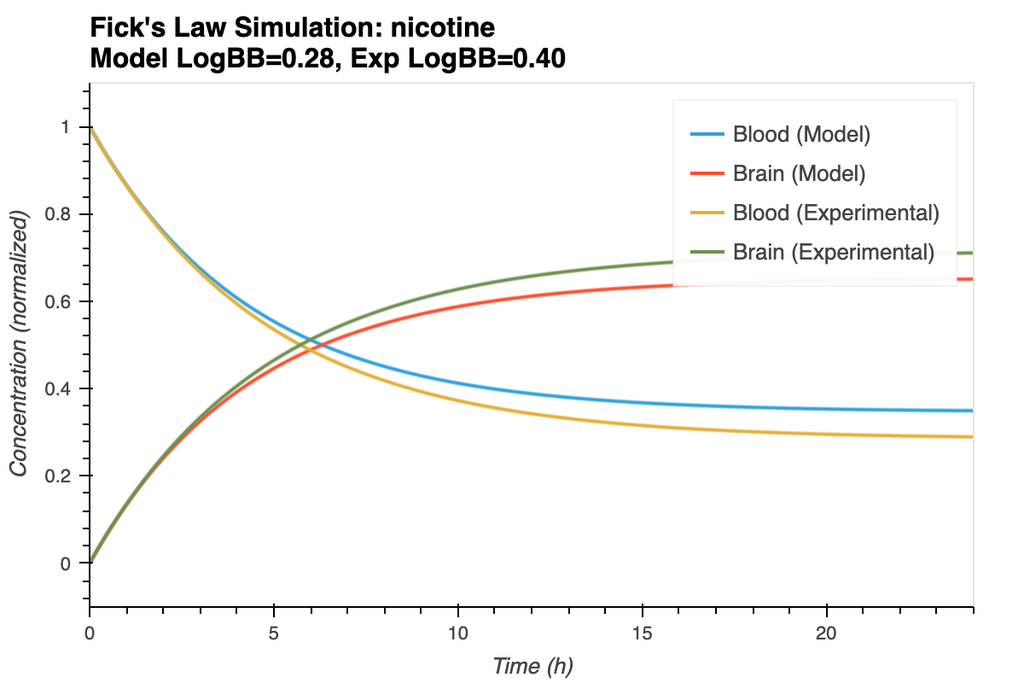

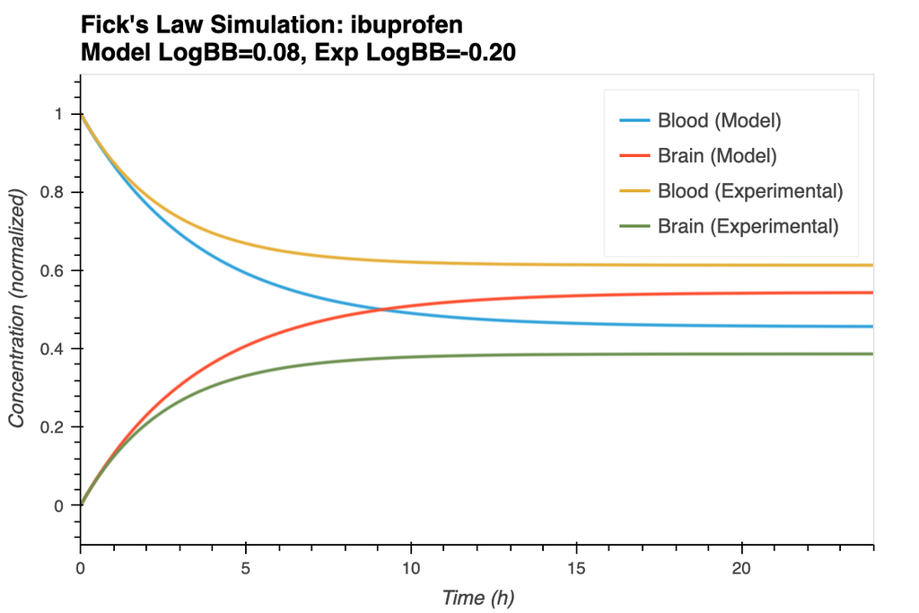

Simulation outputs for nicotine and ibuprofen illustrated both strengths and limitations of the model. For nicotine, predicted and experimental curves aligned closely, while for ibuprofen, the simulation deviated from observed data, highlighting biological factors not captured by descriptors alone.

### Discussion

The results confirm that descriptor‑based models can capture major trends in BBB permeability but remain limited in accuracy. Correlation analysis showed TPSA as the most negatively correlated descriptor and MolLogP as the most positively correlated, consistent with expectations about polarity and lipophilicity. Regression weights further emphasized the influence of aromatic rings (negative contribution) and formal charge (positive contribution).

Gradient boosting provided modest improvements in predictive accuracy and revealed feature importance rankings, with TPSA, MolLogP, and MolWt contributing most to reducing error. The difference in results for the MLR coefficients and feature importance plot highlighted the complex nonlinear relationships involved in BBB permeability.

Our simulation added a dynamic dimension by combining Fick's first law of diffusion with a simplified physiologically-based pharmacokinetic (PBPK) framework. In a full PBPK model, the brain compartment would be described by blood flow, tissue volume, partition coefficients, and clearance terms. We reduced this complexity to a two-compartment blood-brain system shaped by by Fick's law, where flux is proportional to the concentration difference and scaled by the partition ratio $K = 10^{\text{LogBB}}$. The determinant equations: $$ \begin{align} \frac{d C_b}{dt} &= -P_{eff} \cdot (C_b - \frac{C_{br}}{K}) \\ \\ \frac{d C_{br}}{dt} &= P_{eff} \cdot (C_b - \frac{C_{br}}{K} ) \end{align} $$ capture redistribution between blood and brain until equilibrium is reached. This simplification removes explicit blood flow and clearance terms, replacing them with a lumped permeability constant $P_{eff}$. It shows how LogBB predictions translate into time‑dependent concentration changes, while remaining computationally accessible. At the same time, the absence of clearance and active transport explains why predictions aligned well for nicotine but deviated for ibuprofen.

Overall, while our models demonstrate the feasibility of predicting BBB permeability from simple descriptors, their limited accuracy and inability to capture complex biological processes mean they are best viewed in this stage as proof‑of‑concept tools rather than clinically reliable predictors.

## Next Steps

Future work should expand the model by incorporating additional descriptors and larger datasets to improve accuracy and reduce bias. Accounting for drug efflux mechanisms and active transport processes will be critical for capturing real biological dynamics. Validation through preclinical studies and eventual clinical trials will provide essential benchmarks, ensuring that predictions align with observed brain uptake. Another possible extension is adapting the framework to predict permeability across other membranes, such as those in the central nervous system.